# Lab #5 Differential expression

Xulin Ge

Jul 16 2023

We will be working with a small data set run on the rat RAE230A Affymetrix array

The study was to determine differences in mRNA levels between brain hippocampi of animals fed a ketogenic diet (KD) and animals fed a control diet. “KD is an anticonvulsant treatment used to manage medically intractable epilepsies”. The differences between the 2 groups of rats can provide biological insight into the genes that are regulated due to the treatment

We are going to conduct a two-sample test for each gene/probe on the array and then identify those genes/probes that are differentially expressed between the 2 rat diet groups and plot the results with a couple of different visual summaries.

```r
# installing/loading the package:

# No package is required in this lab
```

```r
# Set the directory
(WD <- getwd())
if (!is.null(WD)) setwd(WD)
```

# Read data set into R

Load the rat ketogenic brain data set

```r
# using the read.table() function
txt_file <- "rat_KD.txt"
dat <- read.table(file=file.path("data", txt_file), header=T, row.names=1)
colnames(dat)
```

```
##  [1] "control.diet.19300"   "control.diet.19301"   "control.diet.19302"
##  [4] "control.diet.19303"   "control.diet.19304"   "control.diet.19305"
##  [7] "ketogenic.diet.19306" "ketogenic.diet.19307" "ketogenic.diet.19308"
## [10] "ketogenic.diet.19309" "ketogenic.diet.19310"
```

```r
knitr::kable(head(dat), caption="rat ketogenic brain data set")
```

rat ketogenic brain data set

|  | control.diet.19300 | control.diet.19301 | control.diet.19302 | control.diet.19303 | control.diet.19304 | control.diet.19305 | ketogenic.diet.19306 | ketogenic.diet.19307 | ketogenic.diet.19308 | ketogenic.diet.19309 | ketogenic.diet.19310 |
| --- | --- | --- | --- | --- | --- | --- | --- | --- | --- | --- | --- |
| AFFX-BioB-5_at | 76.4424 | 86.0648 | 80.6466 | 93.8439 | 73.1219 | 97.6946 | 82.4622 | 77.2199 | 120.2040 | 98.9692 | 88.2618 |
| AFFX-BioB-M_at | 94.7098 | 73.4476 | 88.6791 | 111.5530 | 92.1317 | 96.4250 | 131.2820 | 114.9030 | 156.7290 | 117.2050 | 119.6470 |
| AFFX-BioB-3_at | 27.8835 | 44.5481 | 33.8824 | 60.0250 | 39.2463 | 37.6365 | 42.7933 | 50.0889 | 78.2358 | 47.8521 | 36.9666 |
| AFFX-BioC-5_at | 174.3390 | 151.8240 | 167.4290 | 200.4780 | 170.7280 | 196.7960 | 192.0890 | 206.3390 | 236.0370 | 202.8170 | 185.8010 |
| AFFX-BioC-3_at | 87.0285 | 94.0345 | 120.2830 | 114.5800 | 100.1920 | 88.3586 | 122.3530 | 130.9680 | 157.4380 | 110.3880 | 117.7130 |
| AFFX-BioDn-5_at | 150.1180 | 135.4670 | 163.3840 | 170.9000 | 155.7970 | 145.5060 | 156.8610 | 163.5470 | 210.0430 | 183.8350 | 172.9660 |

# Student’s t-test

First log2 the data

```r
dat2 <- log2(dat)
```

From the column names listed above, we know that column 1:6 is control diet class and column 7:11 is ketogenic diet class. So, we can use the `names()` function to determine where one class ends and the other begins

```r
# two diet classes determined by names() function
cl <- names(dat2)
ctrl <- cl[1:6]
KO <- cl[7:11]
```

Then use the Student’s t-test function to calculate the changing genes between the control diet and ketogenic diet classes

```r
# function to calculate Student’s two-sample t-test on all genes at once
# function returns the p-value for the test
# NAs are removed for each test
# s1 and s2 are dimensions of the two samples
# run function on each gene in the data frame
t.test.all.genes <- function(x,s1,s2) {
    x1 <- x[s1]
    x2 <- x[s2]
    x1 <- as.numeric(x1)
    x2 <- as.numeric(x2)
    t.out <- t.test(x1,x2, alternative="two.sided",var.equal=T)
    out <- as.numeric(t.out$p.value)
    return(out)
}

# use the Student’s t-test function to calculate the changing genes
# between the control diet and ketogenic diet classes
pv <- apply(dat2, 1, t.test.all.genes, s1=ctrl, s2=KO)
knitr::kable(head(pv), caption="p-values using a Student's t-test")
```

p-values using a Student’s t-test

|  | x |
| --- | --- |
| AFFX-BioB-5_at | 0.3199816 |
| AFFX-BioB-M_at | 0.0030404 |
| AFFX-BioB-3_at | 0.1954937 |
| AFFX-BioC-5_at | 0.0374438 |
| AFFX-BioC-3_at | 0.0175999 |
| AFFX-BioDn-5_at | 0.0401465 |

# Histogram of the p-values

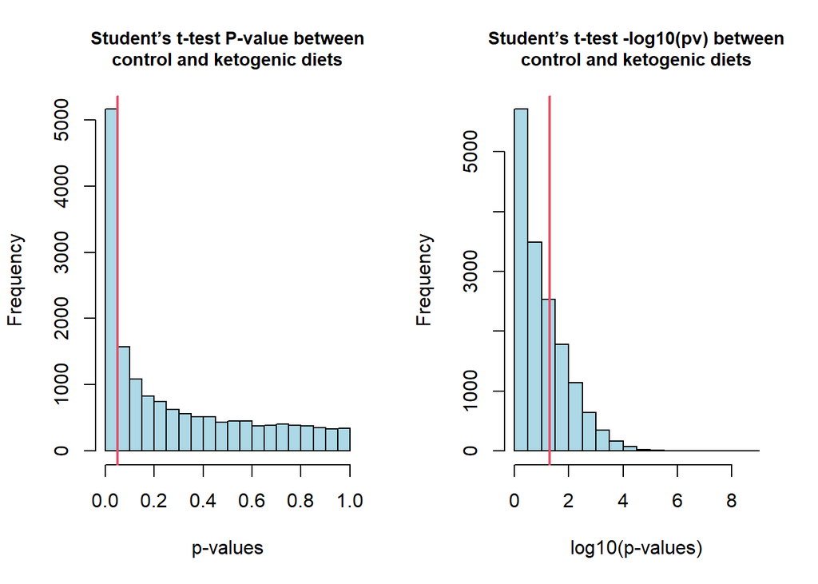

```r
par(mfrow=c(1,2))
hist(pv, col="lightblue", xlab="p-values",
    main="Student’s t-test P-value between\ncontrol and ketogenic diets", cex.main=0.9)
abline(v=.05, col=2, lwd=2)
hist(-log10(pv), col="lightblue", xlab="log10(p-values)",
    main="Student’s t-test -log10(pv) between\ncontrol and ketogenic diets", cex.main=0.9)
abline(v= -log10(.05), col=2, lwd=2)
```

### Report how many probesets have a p<.05 and p<.01

```r
length(pv[pv<0.05])
```

```
## [1] 5160
```

```r
length(pv[pv<0.01])
```

```
## [1] 2414
```

5160 probesets have a p value <.05 and 2414 probesets have a p value <.01.

### Bonferroni correction - a very conservative p-value thresholding method to account for multiple testing:

Divide an alpha of 0.05 by the total number of probesets and report how many probesets have a p-value less than this value

```r
alpha <- 0.05/length(dat2[,1])
alpha
```

```
## [1] 3.140112e-06
```

```r
length(pv[pv<alpha])
```

```
## [1] 12
```

12 probesets have a p-value less than this alpha value

### Calculate the mean for each gene

```r
ctrl.m <- apply(dat2[,ctrl], 1, mean, na.rm=T)
KO.m <- apply(dat2[,KO], 1, mean, na.rm=T)
```

### Calculate the fold change between the groups (control vs. ketogenic diet)

```r
fold <- ctrl.m-KO.m
knitr::kable(head(fold), caption="fold change between the control vs. ketogenic diet groups")
```

fold change between the control vs. ketogenic diet groups

|  | x |
| --- | --- |
| AFFX-BioB-5_at | -0.1324016 |
| AFFX-BioB-M_at | -0.4641657 |
| AFFX-BioB-3_at | -0.3293078 |
| AFFX-BioC-5_at | -0.2113334 |
| AFFX-BioC-3_at | -0.3429443 |
| AFFX-BioDn-5_at | -0.2053881 |

### Report the maximum and minimum fold change value on the linear scale

```r
summary(fold)
```

```
##     Min.  1st Qu.   Median     Mean  3rd Qu.     Max.
## -3.60113 -0.12229  0.08656  0.09723  0.32136  5.78543
```

```r
# 2^log scale value
fold.linear <- 2^fold
max(fold.linear)
```

```
## [1] 55.15521
```

```r
min(fold.linear)
```

```
## [1] 0.08240443
```

```r
2^5.78543
```

```
## [1] 55.15539
```

```r
2^-3.6011
```

```
## [1] 0.08240639
```

On the linear scale, the maximum fold change is 55.15521 and minimum fold change is 0.08240443

### Report the probesets that meets:

1. a p-value less than the Bonferroni threshold used above and
2. |fold change|>2

Note that we were on a log2 scale for the fold change and we are looking for a linear |fold| of 2

```r
pv.filter <- pv[pv<alpha & abs(fold.linear)>2]
length(pv.filter)
```

```
## [1] 6
```

There are 6 probesets meet the requirements.

### Go to NetAffx or another database source

Identify gene information for the probesets that meet the Bonferroni threshold requirements. What is the general biological function that associates with these probesets?

```r
names(pv.filter)
```

```
## [1] "1367553_x_at" "1370239_at"   "1370240_x_at" "1371102_x_at" "1371245_a_at"
## [6] "1388608_x_at"
```

Search these probesets on biogps:

1367553_x_at

Hbb (hemoglobin subunit beta)

http://biogps.org/#goto=genereport&id=24440

1370239_at

1370240_x_at

1388608_x_at

Hba-a2 (hemoglobin alpha, adult chain 2)

http://biogps.org/#goto=genereport&id=360504

1371102_x_at

1371245_a_at

Hbb-bs (hemoglobin, beta adult s chain)

http://biogps.org/#goto=genereport&id=689064

We can see that these 6 probesets are all for hemoglobins (biological function) in rat, with 3 probesets mapping to the same gene

# Volcano plot

### Transform the p-value (-1*log10(p-value))

Make sure to use a log10 transformation for the p-value and a log2 transformation for the fold change

```r
# fold is already in log2 scale, transform pv
p.trans <- -1*log10(pv)
```

### Create a volcano plot with the p-value and fold change vectors

Draw the horizontal lines at fold values of 2 and -2 (log2 value=1) and the vertical p-value threshold line at p=.05 (remember that it is transformed in the plot).

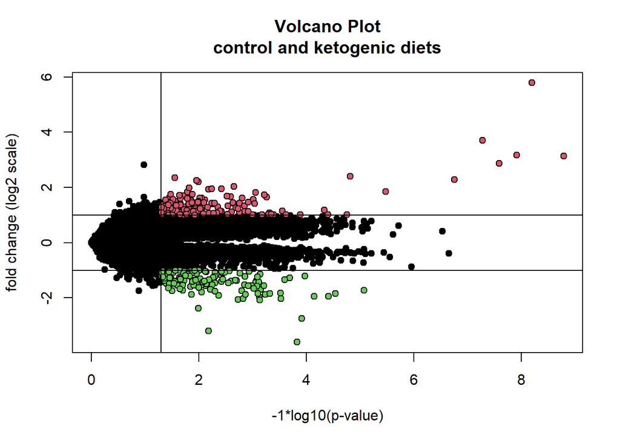

```r
# create a volcano plot with the p-value and fold change vectors
plot(range(p.trans),range(fold), type='n', xlab='-1*log10(p-value)', ylab='fold change (log2 scale)',
    main='Volcano Plot\ncontrol and ketogenic diets')
points(p.trans,fold,col='black',pch=21,bg=1)

# Draw the horizontal lines at fold values of 2 and -2 (log2 value=1) and
# the vertical p-value threshold line at p=.05 (remember that it is transformed in the plot)
points(p.trans[(p.trans> -log10(.05)&fold>log2(2))],fold[(p.trans> -log10(.05)&fold>log2(2))],col=1,bg=2,pch=21)
points(p.trans[(p.trans> -log10(.05)&fold< -log2(2))],fold[(p.trans> -log10(.05)&fold< -log2(2))],col=1,bg=3,pch=21)
abline(v= -log10(.05))
abline(h= -log2(2))
abline(h=log2(2))
```